Corpus Linguistics with R: An Introduction Alvin Cheng-Hsien Chen Jan. @ TU, Dresden  
👉 [Launch Tutorial in Binder](https://mybinder.org/v2/gh/alvinntnu/Corpus_Linguistics_TU_Dresden/main?urlpath=rstudio)

👉 [Launch Tutorial in Binder](https://mybinder.org/v2/gh/alvinntnu/Corpus_Linguistics_TU_Dresden/main?urlpath=rstudio)

# 1 Corpus Analysis: A Start

In this tutorial, I will demonstrate how to perform a basic corpus analysis after you have collected data. I will show you some of the most common ways that people work with the text data.

# 2 Installing `quanteda`

There are many packages that are made for computational text analytics in R. You may consult the [CRAN Task View: Natural Language Processing](https://cran.r-project.org/web/views/NaturalLanguageProcessing.html) for a lot more alternatives.

To start with, this tutorial will use a powerful package, `quanteda`, for managing and analyzing textual data in R. You may refer to the [official documentation of the package](https://quanteda.io/) for more detail.

`quanteda` is not included in the default R installation. Please install the package if you haven’t done so.

```r
install.packages("quanteda")
install.packages("readtext")
```

Also, as noted on the `quanteda` documentation, because this library compiles some C++ and Fortran source code, you will need to have installed the appropriate compilers.

- If you are using a Windows platform, this means you will need also to install the [Rtools](https://cran.r-project.org/bin/windows/Rtools/) software available from CRAN.
- If you are using macOS, you should install the [macOS tools](https://cran.r-project.org/bin/macosx/tools/).

If you run into any installation errors, please go to the official documentation page for additional assistance.

```r
library(tidyverse)
library(quanteda)
library(readtext)
library(tidytext)

packageVersion("quanteda")
```

```
## [1] '4.1.0'
```

# 3 Building a `corpus` from character vector

To demonstrate a typical corpus analytic example with texts, I will be using a pre-loaded corpus that comes with the `quanteda` package, `data_corpus_inaugural`. This is a corpus of US presidential inaugural address texts, and metadata for the corpus from 1789 to present.

```r
data_corpus_inaugural
```

```
## Corpus consisting of 59 documents and 4 docvars.
## 1789-Washington :
## "Fellow-Citizens of the Senate and of the House of Representa..."
##
## 1793-Washington :
## "Fellow citizens, I am again called upon by the voice of my c..."
##
## 1797-Adams :
## "When it was first perceived, in early times, that no middle ..."
##
## 1801-Jefferson :
## "Friends and Fellow Citizens: Called upon to undertake the du..."
##
## 1805-Jefferson :
## "Proceeding, fellow citizens, to that qualification which the..."
##
## 1809-Madison :
## "Unwilling to depart from examples of the most revered author..."
##
## [ reached max_ndoc ... 53 more documents ]
```

```r
class(data_corpus_inaugural)
```

```
## [1] "corpus"    "character"
```

We create a `corpus()` object with the pre-loaded `corpus` in `quanteda`– `data_corpus_inaugural`:

```r
corp_us <- corpus(data_corpus_inaugural) # save the `corpus` to a short obj name
```

After the `corpus` is loaded, we can use `summary()` to get the metadata of each text in the corpus, including word types and tokens as well. This allows us to have a quick look at the size of the addressess made by all presidents.

```r
summary(corp_us)
```

|  | Text | Types | Tokens | Sentences | Year | President | FirstName | Party |
| --- | --- | --- | --- | --- | --- | --- | --- | --- |
| 1 | 1789-Washington | 625 | 1537 | 23 | 1789 | Washington | George | none |
| 2 | 1793-Washington | 96 | 147 | 4 | 1793 | Washington | George | none |
| 3 | 1797-Adams | 826 | 2577 | 37 | 1797 | Adams | John | Federalist |
| 4 | 1801-Jefferson | 717 | 1923 | 41 | 1801 | Jefferson | Thomas | Democratic-Republican |
| 5 | 1805-Jefferson | 804 | 2380 | 45 | 1805 | Jefferson | Thomas | Democratic-Republican |
| 6 | 1809-Madison | 535 | 1261 | 21 | 1809 | Madison | James | Democratic-Republican |
| 7 | 1813-Madison | 541 | 1302 | 33 | 1813 | Madison | James | Democratic-Republican |
| 8 | 1817-Monroe | 1040 | 3677 | 121 | 1817 | Monroe | James | Democratic-Republican |
| 9 | 1821-Monroe | 1259 | 4886 | 131 | 1821 | Monroe | James | Democratic-Republican |
| 10 | 1825-Adams | 1003 | 3147 | 74 | 1825 | Adams | John Quincy | Democratic-Republican |

[output cut: 49 more lines]

If you like to add document-level metadata information to each document in the `corpus` object, you can use `docvars()`. These document-level metadata information is referred to as `docvars` (document variables) in `quanteda`.

```
docvars(corp_us, "country") <- "US"
```

The advantages of these `docvars` is that we can easily subset the corpus based on these document-level variables (i.e., a new corpus can be extracted/created based on logical conditions applied to `docvars`):

```r
corpus_subset(corp_us, Year > 2000) %>%
  summary
```

|  | Text | Types | Tokens | Sentences | Year | President | FirstName | Party |
| --- | --- | --- | --- | --- | --- | --- | --- | --- |
| 1 | 2001-Bush | 621 | 1806 | 97 | 2001 | Bush | George W. | Republican |
| 2 | 2005-Bush | 772 | 2312 | 99 | 2005 | Bush | George W. | Republican |
| 3 | 2009-Obama | 938 | 2689 | 110 | 2009 | Obama | Barack | Democratic |
| 4 | 2013-Obama | 814 | 2317 | 88 | 2013 | Obama | Barack | Democratic |
| 5 | 2017-Trump | 582 | 1660 | 88 | 2017 | Trump | Donald J. | Republican |
| 6 | 2021-Biden | 812 | 2766 | 216 | 2021 | Biden | Joseph R. | Democratic |

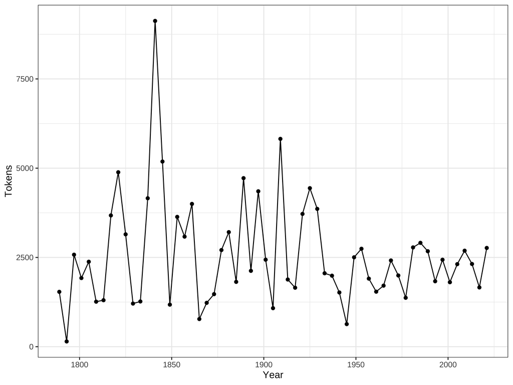

```r
require(ggplot2)

corp_us %>%
  summary %>%
  ggplot(aes(x = Year, y = Tokens, group = 1)) +
    geom_line() +
    geom_point() +
    theme_bw()
```

Could you reproduce the above line plot and add information of `President` to the plot as labels of the dots?

Hints: Please check `ggplot2::geom_text()` or more advanced one, `ggrepel::geom_text_repel()`

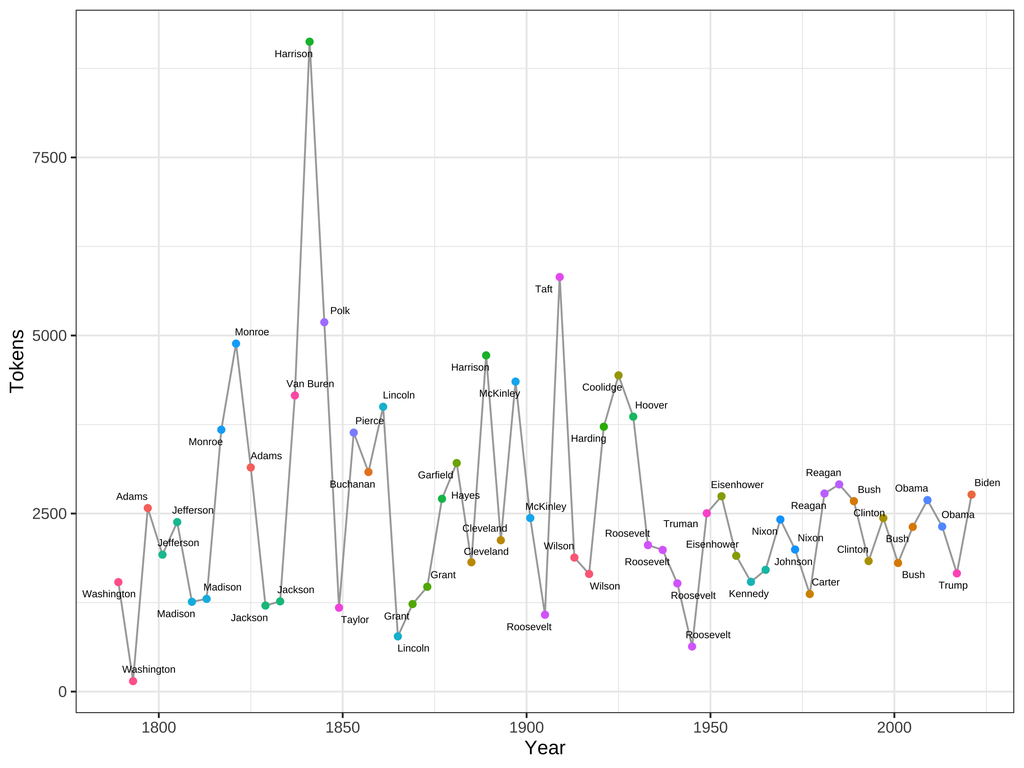

So the idea is that as long as you can load the text data into a character vector, you can easily create an `corpus` object with `quanteda::corpus()`.

The library `readtext` provides a very effective function `readtext()` for you to load text data from external files. Please check its documentation for more effective usages.

For example, if you have downloaded the file `gutenberg.zip` and stored it in `demo_data`, you can load in the `gutenberg` corpus as follows:

```r
gutenberg <- readtext(file = "demo_data/gutenberg.zip")
gutenberg_corp <- corpus(gutenberg)
summary(gutenberg_corp)
```

|  | Text | Types | Tokens | Sentences |
| --- | --- | --- | --- | --- |
| 1 | austen-emma.txt | 8032 | 196390 | 7318 |
| 2 | austen-persuasion.txt | 6294 | 97562 | 3648 |
| 3 | austen-sense.txt | 7005 | 142680 | 4781 |
| 4 | bible-kjv.txt | 13992 | 1007239 | 29804 |
| 5 | blake-poems.txt | 1844 | 8169 | 352 |
| 6 | bryant-stories.txt | 4538 | 55436 | 2720 |
| 7 | burgess-busterbrown.txt | 1778 | 18237 | 998 |
| 8 | carroll-alice.txt | 3070 | 34074 | 1614 |
| 9 | chesterton-ball.txt | 9162 | 97247 | 4683 |
| 10 | chesterton-brown.txt | 8652 | 85034 | 3747 |

[output cut: 8 more lines]

# 4 Keyword-in-Context (KWIC)

Keyword-in-Context (KWIC), or *concordances*, are the most frequently used method in corpus linguistics. The idea is very intuitive: we get to know more about the semantics of a word by examining how it is being used in a wider context.

We first tokenize the corpus using `tokens()` and then we can use `kwic()` to perform a search for a word and retrieve its concordances from the corpus:

```r
## word tokenization
corp_us_tokens <- tokens(corp_us)
## concordances
kwic(corp_us_tokens, "terror")
```

| docname | from | to | pre | keyword | post | pattern |
| --- | --- | --- | --- | --- | --- | --- |
| 1797-Adams | 1324 | 1324 | fraud or violence , by | terror | , intrigue , or venality | terror |
| 1933-Roosevelt | 111 | 111 | nameless , unreasoning , unjustified | terror | which paralyzes needed efforts to | terror |
| 1941-Roosevelt | 285 | 285 | seemed frozen by a fatalistic | terror | , we proved that this | terror |
| 1961-Kennedy | 850 | 850 | alter that uncertain balance of | terror | that stays the hand of | terror |
| 1981-Reagan | 811 | 811 | freeing all Americans from the | terror | of runaway living costs . | terror |
| 1997-Clinton | 1047 | 1047 | They fuel the fanaticism of | terror | . And they torment the | terror |
| 1997-Clinton | 1647 | 1647 | maintain a strong defense against | terror | and destruction . Our children | terror |
| 2009-Obama | 1619 | 1619 | advance their aims by inducing | terror | and slaughtering innocents , we | terror |

`kwic()` returns a data frame, which can be easily exported to a CSV file for later use.

Please note that `kwic()`, when taking a `corpus` object as the argument, will automatically *tokenize* the corpus data and do the keyword-in-context search on a *word* basis. Yet, the recommended way is to tokenize the `corpus` object first with `tokens()` before you perform the concordance analysis with `kwic()`.

The pattern you look for cannot be a linguistic pattern across several words. We will talk about how to extract phrasal patterns/constructions later. Also, for languages without explicit word boundaries (e.g., Chinese), this may be a problem with `quanteda`. We will talk more about this in the later chapter on Chinese Texts Analytics.

# 5 KWIC with Regular Expressions

For more complex searches, we can use regular expressions as well in `kwic()`. For example, if you want to include `terror` and all its other related word forms, such as `terrorist`, `terrorism`, `terrors`, you can create a regular expression for the concordances.

```r
kwic(corp_us_tokens, "terror.*", valuetype = "regex") %>%
  data.frame
```

| docname | from | to | pre | keyword | post | pattern |
| --- | --- | --- | --- | --- | --- | --- |
| 1797-Adams | 1324 | 1324 | fraud or violence , by | terror | , intrigue , or venality | terror.* |
| 1933-Roosevelt | 111 | 111 | nameless , unreasoning , unjustified | terror | which paralyzes needed efforts to | terror.* |
| 1941-Roosevelt | 285 | 285 | seemed frozen by a fatalistic | terror | , we proved that this | terror.* |
| 1961-Kennedy | 850 | 850 | alter that uncertain balance of | terror | that stays the hand of | terror.* |
| 1961-Kennedy | 972 | 972 | of science instead of its | terrors | . Together let us explore | terror.* |
| 1981-Reagan | 811 | 811 | freeing all Americans from the | terror | of runaway living costs . | terror.* |
| 1981-Reagan | 2187 | 2187 | understood by those who practice | terrorism | and prey upon their neighbors | terror.* |
| 1997-Clinton | 1047 | 1047 | They fuel the fanaticism of | terror | . And they torment the | terror.* |
| 1997-Clinton | 1647 | 1647 | maintain a strong defense against | terror | and destruction . Our children | terror.* |
| 2009-Obama | 1619 | 1619 | advance their aims by inducing | terror | and slaughtering innocents , we | terror.* |

[output cut: 2 more lines]

By default, the `kwic()` is word-based. If you like to look up a multiword combination, use `phrase()`:

```r
kwic(corp_us_tokens, phrase("our country")) %>%
  data.frame
```

| docname | from | to | pre | keyword | post | pattern |
| --- | --- | --- | --- | --- | --- | --- |
| 1801-Jefferson | 18 | 19 | the first executive office of | our country | , I avail myself of | our country |
| 1805-Jefferson | 1898 | 1899 | course , I offer to | our country | sincere congratulations . With those | our country |
| 1809-Madison | 322 | 323 | from this prosperous condition of | our country | to the scene which has | our country |
| 1813-Madison | 1033 | 1034 | and an intelligent people . | Our country | abounds in the necessaries , | our country |
| 1813-Madison | 1226 | 1227 | arms now may long preserve | our country | from the necessity of another | our country |
| 1817-Monroe | 1217 | 1218 | the highly favored condition of | our country | , it is the interest | our country |
| 1817-Monroe | 2328 | 2329 | among which the improvement of | our country | by roads and canals , | our country |
| 1821-Monroe | 265 | 266 | , prosperity and happiness of | our country | will always be the object | our country |
| 1821-Monroe | 1203 | 1204 | citizens from that destruction and | our country | from that devastation which are | our country |
| 1821-Monroe | 4028 | 4029 | to the internal concerns of | our country | , and more especially to | our country |

[output cut: 93 more lines]

It should be noted that the output of `kwic` includes not only the concordances (i.e., preceding/subsequent co-texts + the keyword), but also the sources of the texts for each concordance line. This would be extremely convenient if you need to refer back to the original discourse context of the concordance line.

After a series of trial and error attempts, it seems that `phrase()` also supports regular expression search. If we want to extract the concordances of a multiword pattern defined by a regular expression, we can specify the regular expression on a **word** basis and change the `valuetype` to be `regex`.

It is less clear to me how we can use the regular expression to retrieve multiword patterns of variable sizes with `kwic()`.

```r
kwic(corp_us_tokens,
     phrase("^(the|our)$ ^countr.+?$"),
     valuetype = "regex") %>%
  data.frame
```

| docname | from | to | pre | keyword | post | pattern |
| --- | --- | --- | --- | --- | --- | --- |
| 1801-Jefferson | 18 | 19 | the first executive office of | our country | , I avail myself of | ^(the\|our)$ ^countr.+?$ |
| 1805-Jefferson | 1898 | 1899 | course , I offer to | our country | sincere congratulations . With those | ^(the\|our)$ ^countr.+?$ |
| 1809-Madison | 322 | 323 | from this prosperous condition of | our country | to the scene which has | ^(the\|our)$ ^countr.+?$ |
| 1813-Madison | 1033 | 1034 | and an intelligent people . | Our country | abounds in the necessaries , | ^(the\|our)$ ^countr.+?$ |
| 1813-Madison | 1226 | 1227 | arms now may long preserve | our country | from the necessity of another | ^(the\|our)$ ^countr.+?$ |
| 1817-Monroe | 1217 | 1218 | the highly favored condition of | our country | , it is the interest | ^(the\|our)$ ^countr.+?$ |
| 1817-Monroe | 2026 | 2027 | the great naval resources of | the country | render it susceptible , and | ^(the\|our)$ ^countr.+?$ |
| 1817-Monroe | 2221 | 2222 | patriotism and youthful vigor of | the country | . If formed on equal | ^(the\|our)$ ^countr.+?$ |
| 1817-Monroe | 2328 | 2329 | among which the improvement of | our country | by roads and canals , | ^(the\|our)$ ^countr.+?$ |
| 1817-Monroe | 2373 | 2374 | much to the ornament of | the country | , and , what is | ^(the\|our)$ ^countr.+?$ |

[output cut: 174 more lines]

```r
kwic(corp_us_tokens,
     phrase("^(be|was|were)$ ^(\\w+ly)$ ^(\\w+ed)$"),
     valuetype = "regex") %>%
  data.frame
```

| docname | from | to | pre | keyword | post | pattern |
| --- | --- | --- | --- | --- | --- | --- |
| 1789-Washington | 1242 | 1244 | how far the former can | be impregnably fortified | or the latter be safely | ^(be\|was\|were)$ ^(\\w+ly)$ ^(\\w+ed)$ |
| 1789-Washington | 1368 | 1370 | the personal emoluments which may | be indispensably included | in a permanent provision for | ^(be\|was\|were)$ ^(\\w+ly)$ ^(\\w+ed)$ |
| 1801-Jefferson | 1407 | 1409 | expense , that labor may | be lightly burthened | ; the honest payment of | ^(be\|was\|were)$ ^(\\w+ly)$ ^(\\w+ed)$ |
| 1817-Monroe | 169 | 171 | welfare my motives will always | be duly appreciated | and my conduct be viewed | ^(be\|was\|were)$ ^(\\w+ly)$ ^(\\w+ed)$ |
| 1817-Monroe | 2035 | 2037 | susceptible , and which should | be duly fostered | in time . of peace | ^(be\|was\|were)$ ^(\\w+ly)$ ^(\\w+ed)$ |
| 1817-Monroe | 3658 | 3660 | the Almighty that He will | be graciously pleased | to continue to us that | ^(be\|was\|were)$ ^(\\w+ly)$ ^(\\w+ed)$ |
| 1829-Jackson | 545 | 547 | commerce , and manufactures should | be equally favored | , and that perhaps the | ^(be\|was\|were)$ ^(\\w+ly)$ ^(\\w+ed)$ |
| 1837-VanBuren | 702 | 704 | of so vast a region | were deeply fixed | . Distinct sovereignties were in | ^(be\|was\|were)$ ^(\\w+ly)$ ^(\\w+ed)$ |
| 1837-VanBuren | 1336 | 1338 | years ago its rapid failure | was boldly predicted | . Latent and uncontrollable causes | ^(be\|was\|were)$ ^(\\w+ly)$ ^(\\w+ed)$ |
| 1837-VanBuren | 2343 | 2345 | inevitable . Amid these it | was scarcely believed | possible that a scheme of | ^(be\|was\|were)$ ^(\\w+ly)$ ^(\\w+ed)$ |

[output cut: 56 more lines]

Please create a bar plot, showing the number of uses of the word *country* in each president’s address. Please include different variants of the word, e.g., *countries*, *Countries*, *Country*, in your `kwic()` search.

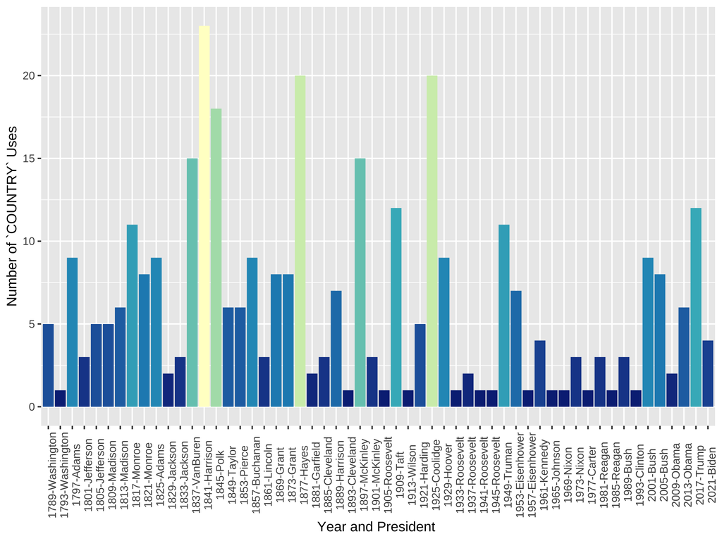

# 6 Tidy Text Format of the Corpus

So far our corpus is a `corpus` object defined in `quanteda`. In most of the R standard packages, people normally follow the **using tidy data principles** to make handling data easier and more effective.

As described by Hadley Wickham (Wickham & Grolemund, 2017), tidy data has a specific structure:

- Each variable is a column
- Each observation is a row
- Each type of observational unit is a table

Essentially, it is an idea of making an abstract object (i.e., `corpus`) a more intuitive data structure, i.e., a `data.frame`, which is easier for human readers to work with.

With text data like a `corpus`, we can also define the **tidy text format** as being a `data.frame` with one-token-per-row.

- A **token** can be any meaningful unit of the text, such as a word that we are interested in using for analysis, and **tokenization** is the process of splitting text into tokens.
- In computational text analytics, the token (i.e., each row in the data frame) is most often a single *word*, but can also be an *n-gram*, a *sentence*, or a *paragraph*.

The `tidytext` package in R is made for the handling of the tidy text format of the corpus data. With a tidy data format of the corpus, we can manipulate the text data with a standard set of *tidy* tools and packages, including `dplyr`, `tidyr`, and `ggplot2`.

The `tidytext` package includes a function, `tidy()`, to convert the `corpus` object from `quanteda` into a **document/text-based** `data.frame`.

```r
library(tidytext)
corp_us_tidy <- tidy(corp_us) # convert `corpus` to `data.frame`
class(corp_us_tidy)
```

```
## [1] "tbl_df"     "tbl"        "data.frame"
```

| text | Year | President | FirstName | Party |
| --- | --- | --- | --- | --- |
| Fellow-Citizens of the Senate and of the House of Representatives:\n\nAmong the vicissitudes incident ... | 1789 | Washington | George | none |
| Fellow citizens, I am again called upon by the voice of my country to execute the functions of its C... | 1793 | Washington | George | none |
| When it was first perceived, in early times, that no middle course for America remained between unli... | 1797 | Adams | John | Federalist |
| Friends and Fellow Citizens:\n\nCalled upon to undertake the duties of the first executive office of o... | 1801 | Jefferson | Thomas | Democratic-Republican |
| Proceeding, fellow citizens, to that qualification which the Constitution requires before my entranc... | 1805 | Jefferson | Thomas | Democratic-Republican |
| Unwilling to depart from examples of the most revered authority, I avail myself of the occasion now ... | 1809 | Madison | James | Democratic-Republican |
| About to add the solemnity of an oath to the obligations imposed by a second call to the station in ... | 1813 | Madison | James | Democratic-Republican |
| I should be destitute of feeling if I was not deeply affected by the strong proof which my fellow-ci... | 1817 | Monroe | James | Democratic-Republican |
| Fellow citizens, I shall not attempt to describe the grateful emotions which the new and very distin... | 1821 | Monroe | James | Democratic-Republican |
| In compliance with an usage coeval with the existence of our Federal Constitution, and sanctioned by... | 1825 | Adams | John Quincy | Democratic-Republican |

[output cut: 49 more lines]

# 7 Processing Flowchart

[interactive chart not shown]

Computational Text Processing Flowchart

# 8 Frequency Lists

## 8.1 Word (Unigram)

To get a frequency list of words, word tokenization is an important step for corpus analysis because words are a meaningful linguistic unit in language. Also, word frequency lists are often indicative of many important messages (e.g., the semantics of the documents).

The `tidytext` provides a powerful function, `unnest_tokens()` to tokenize a data frame with larger linguistic units (e.g., *texts*) into one with smaller units (e.g., *words*). That is, the `unnest_tokens()` convert a **text-based** data frame (each row is a text document) into a **token-based** data frame(each row is a token splitted from the text).

```r
corp_us_words <- corp_us_tidy %>%
  unnest_tokens(output = word, # new base unit column name
                input = text,  # original base unit column name
                token = "words") # tokenization method

corp_us_words
```

| Year | President | FirstName | Party | word |
| --- | --- | --- | --- | --- |
| 1789 | Washington | George | none | fellow |
| 1789 | Washington | George | none | citizens |
| 1789 | Washington | George | none | of |
| 1789 | Washington | George | none | the |
| 1789 | Washington | George | none | senate |
| 1789 | Washington | George | none | and |
| 1789 | Washington | George | none | of |
| 1789 | Washington | George | none | the |
| 1789 | Washington | George | none | house |
| 1789 | Washington | George | none | of |

[output cut: 990 more lines]

The `unnest_tokens()` is optimized for English tokenization of smaller linguistic units, such as *words*, *ngrams*, *sentences*, *lines*, and *paragraphs* (check `?unnest_tokens()`).

Now we can count the word frequencies by making use of the `dplyr` library:

```r
corp_us_words_freq <- corp_us_words %>%
  count(word, sort = TRUE)


corp_us_words_freq
```

| word | n |
| --- | --- |
| the | 10183 |
| of | 7180 |
| and | 5406 |
| to | 4599 |
| in | 2829 |
| a | 2293 |
| our | 2224 |
| we | 1827 |
| that | 1813 |
| be | 1503 |

[output cut: 990 more lines]

## 8.2 Bigrams

Frequency lists can be generated for bigrams or any other multiword combinations as well. The key is we need to convert the **text-based** data frame into a **bigram-based** data frame.

```r
corp_us_bigrams <- corp_us_tidy %>%
  unnest_tokens(
    output = bigram, # new base unit column name
    input = text, # original base unit column name
    token = "ngrams", # tokenization method
    n = 2
  )

corp_us_bigrams
```

| Year | President | FirstName | Party | bigram |
| --- | --- | --- | --- | --- |
| 1789 | Washington | George | none | fellow citizens |
| 1789 | Washington | George | none | citizens of |
| 1789 | Washington | George | none | of the |
| 1789 | Washington | George | none | the senate |
| 1789 | Washington | George | none | senate and |
| 1789 | Washington | George | none | and of |
| 1789 | Washington | George | none | of the |
| 1789 | Washington | George | none | the house |
| 1789 | Washington | George | none | house of |
| 1789 | Washington | George | none | of representatives |

[output cut: 990 more lines]

To create bigram frequency list:

```r
corp_us_bigrams_freq <- corp_us_bigrams %>%
  count(bigram, sort=TRUE)
corp_us_bigrams_freq
```

| bigram | n |
| --- | --- |
| of the | 1772 |
| in the | 821 |
| to the | 727 |
| of our | 628 |
| and the | 474 |
| it is | 324 |
| by the | 322 |
| for the | 315 |
| to be | 314 |
| the people | 270 |

[output cut: 990 more lines]

```r
sum(corp_us_words_freq$n) # size of unigrams
```

```
## [1] 137939
```

```r
sum(corp_us_bigrams_freq$n) # size of bigrams
```

```
## [1] 137880
```

Based on the bigram-based data frame, how can we create a frequency list showing each president’s uses of bigrams with the first-person plural pronoun **we** as the first word.

In the output, please present the most frequently used bigram in each presential addresss only. If there are ties, present all of them.

Arrange the frequency list according to the year, the president’s last name, and the token frequency of the bigram.

| Year | President | bigram | n |
| --- | --- | --- | --- |
| 2021 | Biden | we can | 15 |
| 2017 | Trump | we will | 24 |
| 2013 | Obama | we must | 11 |
| 2009 | Obama | we will | 12 |
| 2005 | Bush | we have | 10 |
| 2005 | Bush | we will | 10 |
| 2001 | Bush | we will | 13 |
| 1997 | Clinton | we will | 6 |
| 1993 | Clinton | we must | 13 |
| 1989 | Bush | we have | 9 |

[output cut: 84 more lines]

The function `unnest_tokens()` does a lot of work behind the scene. Please take a closer look at the outputs of `unnest_tokens()` and examine how it takes care of the **case normalization** and **punctuations** within the sentence. Will these treatments affect the frequency lists we get in any important way? Please elaborate.

## 8.3 Ngrams (Lexical Bundles)

```r
corp_us_trigrams <-  corp_us_tidy %>%
  unnest_tokens(trigrams, text, token = "ngrams", n = 3)

corp_us_trigrams
```

| Year | President | FirstName | Party | trigrams |
| --- | --- | --- | --- | --- |
| 1789 | Washington | George | none | fellow citizens of |
| 1789 | Washington | George | none | citizens of the |
| 1789 | Washington | George | none | of the senate |
| 1789 | Washington | George | none | the senate and |
| 1789 | Washington | George | none | senate and of |
| 1789 | Washington | George | none | and of the |
| 1789 | Washington | George | none | of the house |
| 1789 | Washington | George | none | the house of |
| 1789 | Washington | George | none | house of representatives |
| 1789 | Washington | George | none | of representatives among |

[output cut: 990 more lines]

We then can examine which n-grams were most often used by each President:

```r
corp_us_trigrams %>%
  count(President, trigrams) %>%
  group_by(President) %>%
  top_n(3, n) %>%
  arrange(President, desc(n))
```

| President | trigrams | n |
| --- | --- | --- |
| Adams | of the union | 12 |
| Adams | of the people | 10 |
| Adams | of our country | 6 |
| Biden | here we stand | 5 |
| Biden | all of us | 4 |
| Biden | my fellow americans | 4 |
| Buchanan | the united states | 8 |
| Buchanan | of the united | 7 |
| Buchanan | of the government | 5 |
| Bush | it is the | 7 |

[output cut: 173 more lines]

Please subset the top 3 trigrams of President Don. Trump, Bill Clinton, John Adams, from `corp_us_trigram`.

| President | trigrams | n |
| --- | --- | --- |
| Adams | of the union | 12 |
| Adams | of the people | 10 |
| Adams | of our country | 6 |
| Clinton | a new century | 6 |
| Clinton | my fellow americans | 6 |
| Clinton | land of new | 5 |
| Clinton | of new promise | 5 |
| Trump | we will make | 5 |
| Trump | will make america | 5 |
| Trump | bring back our | 4 |

[output cut: 2 more lines]

# 9 Frequency and Dispersion

When looking at frequency lists, there is another distributional metric we need to consider: **dispersion**.

An n-gram can be meaningful if its frequency is high. However, this high frequency may come in different meanings. What if the n-gram only occurs in ONE particular document, i.e., used only by a particular President? Or alternatively, what if the n-gram appears in many different documents, i.e., used by many different Presidents?

The degrees of n-gram dispersion has a lot to do with the significance of its frequency.

So now let’s compute the `dispersion` of the n-grams in our `corp_us_trigrams`. Here we define the `dispersion` of an n-gram as the number of Presidents who have used the n-gram at least once in his address(es).

Dispersion is an important construct and many more sophisticated quantitative metrics have been proposed to more properly operationalize this concept. Please see Gries (2021).

```r
# method 1
corp_us_trigrams %>%
  count(trigrams, President) %>%
  group_by(trigrams) %>%
  summarize(FREQ = sum(n), DISPERSION = n()) %>%
  filter(DISPERSION >= 5) %>%
  arrange(desc(DISPERSION))
```

| trigrams | FREQ | DISPERSION |
| --- | --- | --- |
| the united states | 152 | 29 |
| of the united | 99 | 27 |
| of the world | 63 | 24 |
| as well as | 47 | 23 |
| of the people | 97 | 23 |
| the people of | 43 | 23 |
| my fellow citizens | 46 | 22 |
| the american people | 39 | 21 |
| it is a | 37 | 20 |
| of our country | 49 | 20 |

[output cut: 873 more lines]

```r
# method2
corp_us_trigrams %>%
  group_by(trigrams) %>%
  summarize(FREQ = n(), DISPERSION = n_distinct(President)) %>%
  filter(DISPERSION >= 5) %>%
  arrange(desc(DISPERSION))
```

| trigrams | FREQ | DISPERSION |
| --- | --- | --- |
| the united states | 152 | 29 |
| of the united | 99 | 27 |
| of the world | 63 | 24 |
| as well as | 47 | 23 |
| of the people | 97 | 23 |
| the people of | 43 | 23 |
| my fellow citizens | 46 | 22 |
| the american people | 39 | 21 |
| it is a | 37 | 20 |
| of our country | 49 | 20 |

[output cut: 873 more lines]

```r
# Arrange according to frequency
# corp_us_trigram %>%
#   count(trigrams, President) %>%
#   group_by(trigrams) %>%
#   summarize(freq = sum(n), dispersion = n()) %>%
#   arrange(desc(freq))
```

In particular, cut-off values are often used to determine a list of meaningful n-grams. These cut-off values include: the **frequency** of the n-grams, as well as the **dispersion** of the n-grams. A subset of n-grams that are defined and selected based on these distributional criteria (i.e., frequency and dispersion) are often referred to as **Lexical bundles** (See Biber, Conrad, & Cortes (2004)).

Please create a list of four-word lexical bundles that have been used in at least FIVE different **presidential addressess**. Arrange the resulting data frame according to the frequency of the four-grams.

| ngrams | FREQ | DISPERSION |
| --- | --- | --- |
| of the united states | 94 | 33 |
| the people of the | 23 | 18 |
| constitution of the united | 20 | 13 |
| the constitution of the | 19 | 12 |
| of the american people | 16 | 14 |
| the united states and | 16 | 10 |
| at the same time | 15 | 13 |
| of the people and | 15 | 10 |
| on the part of | 14 | 10 |
| the nations of the | 14 | 13 |

[output cut: 119 more lines]

# 10 Word Cloud

With frequency data, we can visualize important words in the corpus with a **Word Cloud**. It is a novel but intuitive visual representation of text data. It allows us to quickly perceive the most prominent words from a large collection of texts.

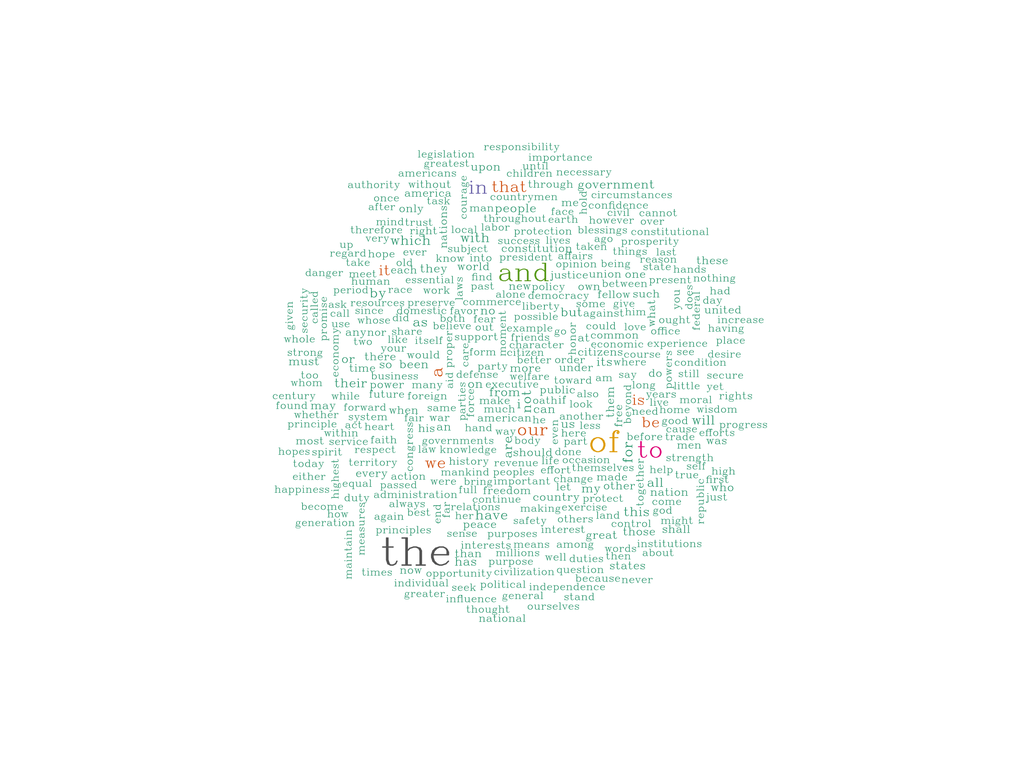

```r
library(wordcloud)
set.seed(123)
with(corp_us_words_freq, wordcloud(word, n,
                                   max.words = 400,
                                   min.freq = 30,
                                   scale = c(2,0.5),
                                   color = brewer.pal(8, "Dark2"),
                                   vfont=c("serif","plain")))
```

Word cloud would be more informative if we first remove functional words. In `tidytext`, there is a preloaded data frame, `stop_words`, which contains common English stop words. Please make use of this data frame and try to re-create a word cloud with all stopwords removed. (Criteria: Frequency >= 20; Max Number of Words Plotted = 400)

Hint: Check `dplyr::anti_join()`

```r
require(tidytext)
stop_words
```

| word | lexicon |
| --- | --- |
| a | SMART |
| a's | SMART |
| able | SMART |
| about | SMART |
| above | SMART |
| according | SMART |
| accordingly | SMART |
| across | SMART |
| actually | SMART |
| after | SMART |

[output cut: 990 more lines]

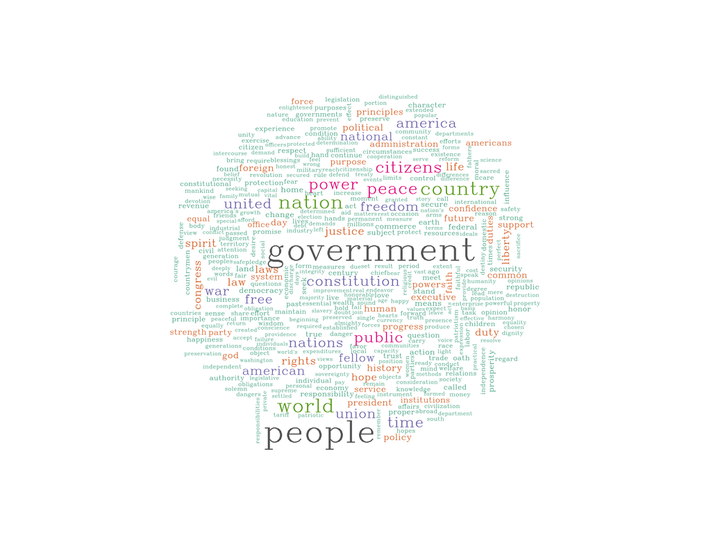

# 11 Collocations

With unigram and bigram frequencies of the corpus, we can further examine the collocations within the corpus. **Collocation** refers to a frequent phenomenon where two words tend to co-occur very often in use. This co-occurrence is defined statistically by their *lexical associations*.

## 11.1 Cooccurrence Table and Observed Frequencies

The cell counts of this contingency table are referred to as the **observed** frequencies *O<sub>11</sub>*, *O<sub>12</sub>*, *O<sub>21</sub>*, and *O<sub>22</sub>*.

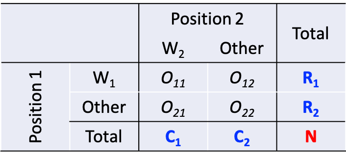

Cooccurrence Frequency Table

The sum of all four observed frequencies (called the sample size *N*) is equal to the total number of bigrams extracted from the corpus.

And before we discuss the computation of lexical associations, there are a few terms that we often use when talking about the contingency table.

- *R<sub>1</sub>* and *R<sub>2</sub>* are the row totals of the observed contingency table, while *C<sub>1</sub>* and *C<sub>2</sub>* are the corresponding column totals. These row and column totals are referred to as **marginal frequencies** (because they are often written on the margins of the table)
- The frequency in *O<sub>11</sub>* is referred to as the **joint frequency** of the two words.

## 11.2 Expected Frequencies

For every contingency table as seen above, if one knows the marginal frequencies (i.e., the row and column sums), one can compute the expected frequencies of the four cells accordingly. These expected frequencies would be the expected distribution under the *null hypothesis* that *W<sub>1</sub>* and *W<sub>2</sub>* are statistically independent.

And the idea of **lexical association** between *W<sub>1</sub>* and *W<sub>2</sub>* is to statistically access to what extent the **observed** frequencies in the contingency table are different from the **expected** frequencies (given the current the **marginal** frequencies).

Therefore, equations for different association measures (i.e., mutual information, log-likelihood ratios, chi-square) are often given in terms of the observed frequencies, marginal frequencies, and the expected frequencies *E<sub>11</sub>*, …, *E<sub>22</sub>*.

Please see Stefan Evert’s [Computational Approaches to Collocation](http://www.collocations.de/AM/index.html) for a very detailed and comprehensive comparison of various statistical methods for lexical association.

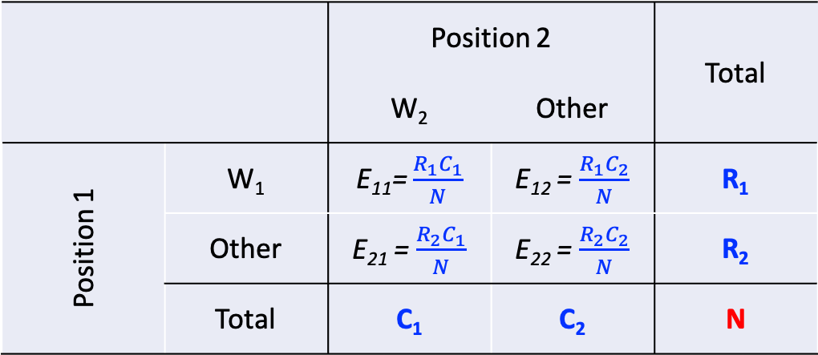

Computing Expected Frequencies

Maybe it would be easier for us to illustrate this with a simple example:

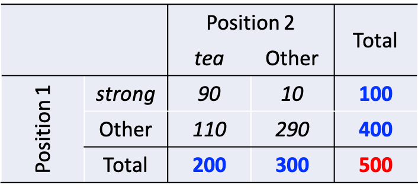

Computing Expected Frequencies

How do we compute the expected frequencies of the four cells?

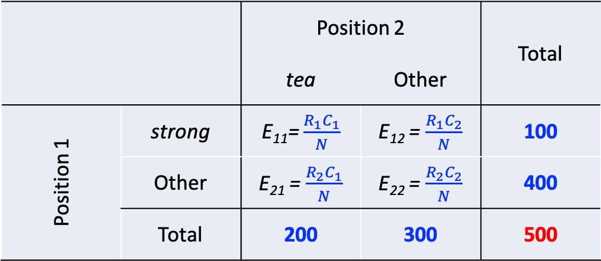

Computing Expected Frequencies

```r
example <- matrix(c(90, 10, 110, 290), byrow=T, nrow=2)
```

Please compute the expected frequencies for the above matrix `example` in R.

|  | tea | OTHER |
| --- | --- | --- |
| strong | 40 | 60 |
| OTHER | 160 | 240 |

## 11.3 Association Measures

The idea of lexical assoication is to measure how much the observed frequencies deviate from the expected. Some of the metrics (e.g., *t-statistic*, *MI*) consider only the joint frequency deviation (i.e., *O<sub>11</sub>*), while others (e.g., *G<sup>2</sup>*, a.k.a Log Likelihood Ratio) consider the deviations of ALL cells.

Here I would like to show you how we can compute the most common two asssociation metrics for all the bigrams found in the corpus: **t-test** statistic and **Mutual Information** (MI).

- $t = \frac{O_{11}-E_{11}}{\sqrt{O_{11}}}$
- $MI = log_2\frac{O_{11}}{E_{11}}$
- $G^2 = 2 \sum_{ij}{O_{ij}log\frac{O_{ij}}{E_{ij}}}$

```r
corp_us_bigrams_freq %>% head(10)
```

| bigram | n |
| --- | --- |
| of the | 1772 |
| in the | 821 |
| to the | 727 |
| of our | 628 |
| and the | 474 |
| it is | 324 |
| by the | 322 |
| for the | 315 |
| to be | 314 |
| the people | 270 |

```r
corp_us_collocations <- corp_us_bigrams_freq %>%
  rename(O11 = n) %>%
  tidyr::separate(bigram, c("w1", "w2"), sep="\\s") %>% # split bigrams into two columns
  mutate(R1 = corp_us_words_freq$n[match(w1, corp_us_words_freq$word)],
         C1 = corp_us_words_freq$n[match(w2, corp_us_words_freq$word)]) %>% # retrieve w1 w2 unigram freq
  mutate(E11 = (R1*C1)/sum(O11)) %>% # compute expected freq of bigrams
  mutate(MI = log2(O11/E11),
         t = (O11 - E11)/sqrt(O11)) %>% # compute associations
  arrange(desc(MI)) # sorting


corp_us_collocations %>%
   filter(O11 > 5) # set bigram frequency cut-off
```

| w1 | w2 | O11 | R1 | C1 | E11 | MI | t |
| --- | --- | --- | --- | --- | --- | --- | --- |
| indian | tribes | 6 | 8 | 6 | 0.0003481288 | 14.073054 | 2.449348 |
| twenty | five | 6 | 16 | 10 | 0.0011604294 | 12.336088 | 2.449016 |
| chief | magistrate | 10 | 37 | 11 | 0.0029518422 | 11.726097 | 3.161344 |
| move | forward | 7 | 16 | 40 | 0.0046417174 | 10.558481 | 2.643997 |
| president | bush | 6 | 96 | 6 | 0.0041775457 | 10.488091 | 2.447784 |
| vice | president | 19 | 21 | 96 | 0.0146214099 | 10.343701 | 4.355545 |
| two | centuries | 8 | 48 | 19 | 0.0066144473 | 10.240164 | 2.826089 |
| interstate | commerce | 6 | 11 | 64 | 0.0051058892 | 10.198585 | 2.447405 |
| domestic | concerns | 7 | 50 | 17 | 0.0061647810 | 10.149090 | 2.643421 |
| god | bless | 16 | 96 | 21 | 0.0146214099 | 10.095774 | 3.996345 |

[output cut: 990 more lines]

Please note that in the above example, we compute the lexical associations for bigrams whose frequency > 5. This is necessary in collocation studies because bigrams of very low frequency would not be informative even though its association can be very strong. However, the cut-off value can be arbitrary, depending on the corpus size or researchers’ considerations.

How to compute lexical associations is a non-trivial issue. There are many more ways to compute the association strengths between two words. Please refer to [Stefan Evert’s site](http://www.collocations.de/index.html) for a very comprehensive review of lexical association measures. Probably the recommended method is *G<sup>2</sup>* (Stefanowitsch, 2019).

The idea of “co-occurrence” can be defined in many different ways. So far, our discussion and computation of bigrams’ collocation strength has been based on a very **narrow** definition of “co-occurrence”, i.e., *w<sub>1</sub>* and *w<sub>2</sub>* have to be directly adjacent to each other (i.e., contiguous bigrams).

The co-occurrence of two words can be defined in more flexible ways:

- *w<sub>1</sub>* and *w<sub>2</sub>* co-occur within a defined window frame (e.g., -/+ ten-word window frame)
- *w<sub>1</sub>* and *w<sub>2</sub>* co-occur within a particular syntactic frame (e.g., Adjective + … + Noun)

While the operationalization of co-occurrence may lead to different *w<sub>1</sub>* and *w<sub>2</sub>* **joint frequencies** in the above contingency table, the computation of the collocation metrics for the two words is still the same.

Sort the collocation data frame `corp_us_collocations` according to the `t-score` and compare the results sorted by `MI` scores. Please describe the differences between the bigram collocations found with both metrics (i.e., MI and t-score).

| w1 | w2 | O11 | R1 | C1 | E11 | MI | t |
| --- | --- | --- | --- | --- | --- | --- | --- |
| of | the | 1772 | 7180 | 10183 | 530.272265738 | 1.7405734 | 29.498133 |
| in | the | 821 | 2829 | 10183 | 208.933181027 | 1.9743406 | 21.361279 |
| of | our | 628 | 7180 | 2224 | 115.813170873 | 2.4389652 | 20.438480 |
| it | is | 324 | 1398 | 1491 | 15.117624021 | 4.4216905 | 17.160132 |
| we | have | 264 | 1827 | 1031 | 13.661422977 | 4.2723583 | 15.407274 |
| to | be | 314 | 4599 | 1503 | 50.132702350 | 2.6469407 | 14.890893 |
| to | the | 727 | 4599 | 10183 | 339.654895561 | 1.0978857 | 14.365835 |
| have | been | 205 | 1031 | 496 | 3.708848274 | 5.7885089 | 14.058784 |
| the | people | 270 | 10183 | 584 | 43.130780389 | 2.6461697 | 13.806821 |
| by | the | 322 | 1091 | 10183 | 80.574796925 | 1.9986601 | 13.454101 |

[output cut: 990 more lines]

Based on the formula provided above, please create a new column for `corp_us_collocations`, which gives the Log-Likelihood Ratios of all the bigrams.

When you do the above exercise, you may run into a couple of problems:

- Some of the bigrams have `NaN` values in their LLR. This may be due to the issue of `NAs produced by integer overflow`. Please solve this.
- After solving the above overflow issue, you may still have a few bigrams with `NaN` in their LLR, which may be due to the computation of the `log` value. In Math, how do we define `log(1/0)` and `log(0/1)`? Do you know when you would get an undefined value `NaN` in the computation of `log()`?
- To solve the problems, please assign the value `0` if the `log` returns `NaN` values.

| w1 | w2 | MI | t | LLR | O11 | O12 | O21 | O22 | E11 | E12 | E21 | E22 |
| --- | --- | --- | --- | --- | --- | --- | --- | --- | --- | --- | --- | --- |
| of | the | 1.7405734 | 29.498133 | 2219.86991 | 1772 | 5408 | 8411 | 122289 | 530.27226573832 | 6649.727734 | 9652.727734 | 121047.3 |
| united | states | 8.3277942 | 12.530684 | 1778.90812 | 158 | 45 | 176 | 137501 | 0.49174644619 | 202.508254 | 333.508254 | 137343.5 |
| it | is | 4.4216905 | 17.160132 | 1513.47406 | 324 | 1074 | 1167 | 135315 | 15.11762402089 | 1382.882376 | 1475.882376 | 135006.1 |
| has | been | 6.3487426 | 13.434583 | 1400.14738 | 185 | 446 | 311 | 136938 | 2.26991586887 | 628.730084 | 493.730084 | 136755.3 |
| have | been | 5.7885089 | 14.058784 | 1381.65495 | 205 | 826 | 291 | 136558 | 3.70884827386 | 1027.291152 | 492.291152 | 136356.7 |
| fellow | citizens | 8.6946013 | 10.790547 | 1367.60426 | 117 | 40 | 131 | 137592 | 0.28239048448 | 156.717610 | 247.717610 | 137475.3 |
| of | our | 2.4389652 | 20.438480 | 1275.02836 | 628 | 6552 | 1596 | 129104 | 115.81317087322 | 7064.186829 | 2108.186829 | 128591.8 |
| in | the | 1.9743406 | 21.361279 | 1219.93475 | 821 | 2008 | 9362 | 125689 | 208.93318102698 | 2620.066819 | 9974.066819 | 125076.9 |
| we | have | 4.2723583 | 15.407274 | 1167.04795 | 264 | 1563 | 767 | 135286 | 13.66142297650 | 1813.338577 | 1017.338577 | 135035.7 |
| those | who | 7.1097543 | 11.275584 | 1120.82053 | 129 | 209 | 252 | 137290 | 0.93398607485 | 337.066014 | 380.066014 | 137161.9 |

[output cut: 990 more lines]

1. Find the top FIVE bigrams ranked according to MI values for each president. The result would be a data frame as shown below. (Please remove bigrams whose frequency < 5 from before ranking.)
2. Create a plot as shown below to visualize your results.

Please note that due to the ties of MI scores, there may be more than five bigrams presented in the results for each presidential address.

| Year_President | bigram | n | w1 | w2 | O11 | R1 | C1 | E11 | MI | t |
| --- | --- | --- | --- | --- | --- | --- | --- | --- | --- | --- |
| 1789_Washington | executive department | 2 | executive | department | 7 | 97 | 24 | 0.0168842472 | 8.695533 | 2.639370 |
| 1789_Washington | fellow citizens | 3 | fellow | citizens | 117 | 157 | 248 | 0.2823904845 | 8.694601 | 10.790547 |
| 1789_Washington | united states | 2 | united | states | 158 | 203 | 334 | 0.4917464462 | 8.327794 | 12.530684 |
| 1789_Washington | derived from | 1 | derived | from | 8 | 9 | 578 | 0.0377284595 | 7.728203 | 2.815088 |
| 1789_Washington | how far | 2 | how | far | 6 | 47 | 89 | 0.0303379751 | 7.627694 | 2.437104 |
| 1793_Washington | chief magistrate | 1 | chief | magistrate | 10 | 37 | 11 | 0.0029518422 | 11.726097 | 3.161344 |
| 1793_Washington | fellow citizens | 1 | fellow | citizens | 117 | 157 | 248 | 0.2823904845 | 8.694601 | 10.790547 |
| 1793_Washington | i am | 2 | i | am | 63 | 871 | 66 | 0.4169277633 | 7.239411 | 7.884726 |
| 1793_Washington | shall endeavor | 1 | shall | endeavor | 8 | 316 | 27 | 0.0618798956 | 7.014385 | 2.806549 |
| 1793_Washington | has been | 1 | has | been | 185 | 631 | 496 | 2.2699158689 | 6.348743 | 13.434583 |

[output cut: 285 more lines]

[figure not shown]

Please note that when you compute the bigram’s collocation strength, their MI values should be same across different presidential addressess. A quick way to check the accuracy of your numbers is to look at the same bigram used in different presidential addresses and see if it has the same MI values.

| Year_President | bigram | n | w1 | w2 | O11 | R1 | C1 | E11 | MI | t |
| --- | --- | --- | --- | --- | --- | --- | --- | --- | --- | --- |
| 1801_Jefferson | domestic concerns | 1 | domestic | concerns | 7 | 50 | 17 | 0.006164781 | 10.14909 | 2.643421 |
| 1817_Monroe | domestic concerns | 1 | domestic | concerns | 7 | 50 | 17 | 0.006164781 | 10.14909 | 2.643421 |
| 1841_Harrison | domestic concerns | 2 | domestic | concerns | 7 | 50 | 17 | 0.006164781 | 10.14909 | 2.643421 |
| 1845_Polk | domestic concerns | 1 | domestic | concerns | 7 | 50 | 17 | 0.006164781 | 10.14909 | 2.643421 |
| 1857_Buchanan | domestic concerns | 1 | domestic | concerns | 7 | 50 | 17 | 0.006164781 | 10.14909 | 2.643421 |
| 1897_McKinley | domestic concerns | 1 | domestic | concerns | 7 | 50 | 17 | 0.006164781 | 10.14909 | 2.643421 |

For example, the above table shows that while in “1801_Jefferson”, there was only one token of the bigram *domestic concerns*, the bigram occurred **7** times in the entire corpus.

# 12 Constructions

We are often interested in the use of linguistic patterns, which are beyond the lexical boundaries. My experience is that usually it is better to work with the corpus on a sentential level.

We can use the same tokenization function, `unnest_tokens()` to convert our **text-based** corpus data frame, `corpus_us_tidy`, into a **sentence-based** tidy structure:

```r
corp_us_sents <- corp_us_tidy %>%
  unnest_tokens(output = sentence, ## nested unit
                input = text, ## superordinate unit
                token = "sentences") # tokenize the `text` column into `sentence`
corp_us_sents
```

| Year | President | FirstName | Party | sentence |
| --- | --- | --- | --- | --- |
| 1789 | Washington | George | none | fellow-citizens of the senate and of the house of representatives: among the vicissitudes incident to life no event could have filled me with greater anxieties than that of which the notification was … |
| 1789 | Washington | George | none | on the one hand, i was summoned by my country, whose voice i can never hear but with veneration and love, from a retreat which i had chosen with the fondest predilection, and, in my flattering hopes, … |
| 1789 | Washington | George | none | on the other hand, the magnitude and difficulty of the trust to which the voice of my country called me, being sufficient to awaken in the wisest and most experienced of her citizens a distrustful scr… |
| 1789 | Washington | George | none | in this conflict of emotions all i dare aver is that it has been my faithful study to collect my duty from a just appreciation of every circumstance by which it might be affected. |
| 1789 | Washington | George | none | all i dare hope is that if, in executing this task, i have been too much swayed by a grateful remembrance of former instances, or by an affectionate sensibility to this transcendent proof of the confi… |
| 1789 | Washington | George | none | such being the impressions under which i have, in obedience to the public summons, repaired to the present station, it would be peculiarly improper to omit in this first official act my fervent suppli… |
| 1789 | Washington | George | none | in tendering this homage to the great author of every public and private good, i assure myself that it expresses your sentiments not less than my own, nor those of my fellow citizens at large less tha… |
| 1789 | Washington | George | none | no people can be bound to acknowledge and adore the invisible hand which conducts the affairs of men more than those of the united states. |
| 1789 | Washington | George | none | every step by which they have advanced to the character of an independent nation seems to have been distinguished by some token of providential agency; and in the important revolution just accomplishe… |
| 1789 | Washington | George | none | these reflections, arising out of the present crisis, have forced themselves too strongly on my mind to be suppressed. |

[output cut: 990 more lines]

With each sentence, we can investigate particular constructions in more detail.

Let’s assume that we are interested in the use of *Perfect* aspect in English by different presidents. We can try to extract Perfect constructions (including Present/Past Perfect) from each sentence using the regular expression.

Here we make a simple naive assumption: Perfect constructions include all `have/has/had + ...-en/ed` tokens from the sentences.

```r
require(stringr)
# Perfect
corp_us_sents %>%
  unnest_tokens(
    perfect,   ## nested unit
    sentence,  ## superordinate unit
    token = function(x)
      str_extract_all(x, "ha(d|ve|s) \\w+(en|ed)")
  ) -> result_perfect
result_perfect
```

| Year | President | FirstName | Party | perfect |
| --- | --- | --- | --- | --- |
| 1789 | Washington | George | none | have filled |
| 1789 | Washington | George | none | had chosen |
| 1789 | Washington | George | none | has been |
| 1789 | Washington | George | none | have been |
| 1789 | Washington | George | none | have then |
| 1789 | Washington | George | none | have advanced |
| 1789 | Washington | George | none | have been |
| 1789 | Washington | George | none | has resulted |
| 1789 | Washington | George | none | have been |
| 1789 | Washington | George | none | have forced |

[output cut: 984 more lines]

In the above example, we specify the `token = ...` in `unnest_tokens(..., token = ...)` with a self-defined function.

The idea of tokenization in `unnest_tokens()` is that the `token` argument can be a function which takes a text-based **vector** as input (i.e, each element of the input vector may be a document text) and returns a **list**, each element of which is a token-based version (i.e., vector) of the original input vector element (see Figure below).

In our demonstration, we define a tokenization function, which takes `sentence` as the input and returns a list, each element of which consists a vector of tokens matching the regular expressions in individual sentences in `sentence`.

(Note: The function object is not assigned to an object name, thus never being created in the R working session.)

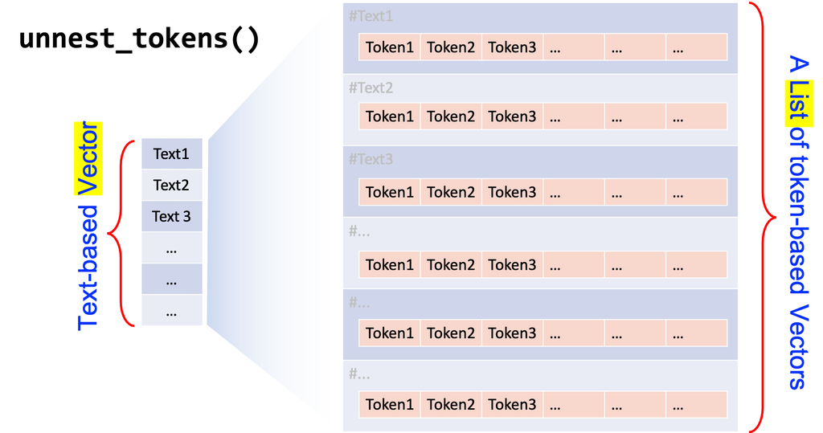

Intuition for `token=` in `unnest_tokens()`

And of course we can do an exploratory analysis of the frequencies of Perfect constructions by different presidents:

```r
require(tidyr)
# table
result_perfect %>%
  group_by(President) %>%
  summarize(TOKEN_FREQ = n(),
            TYPE_FREQ = n_distinct(perfect))
```

| President | TOKEN_FREQ | TYPE_FREQ |
| --- | --- | --- |
| Adams | 62 | 31 |
| Biden | 14 | 8 |
| Buchanan | 29 | 18 |
| Bush | 34 | 24 |
| Carter | 9 | 9 |
| Cleveland | 13 | 11 |
| Clinton | 17 | 13 |
| Coolidge | 32 | 21 |
| Eisenhower | 14 | 12 |
| Garfield | 31 | 20 |

[output cut: 26 more lines]

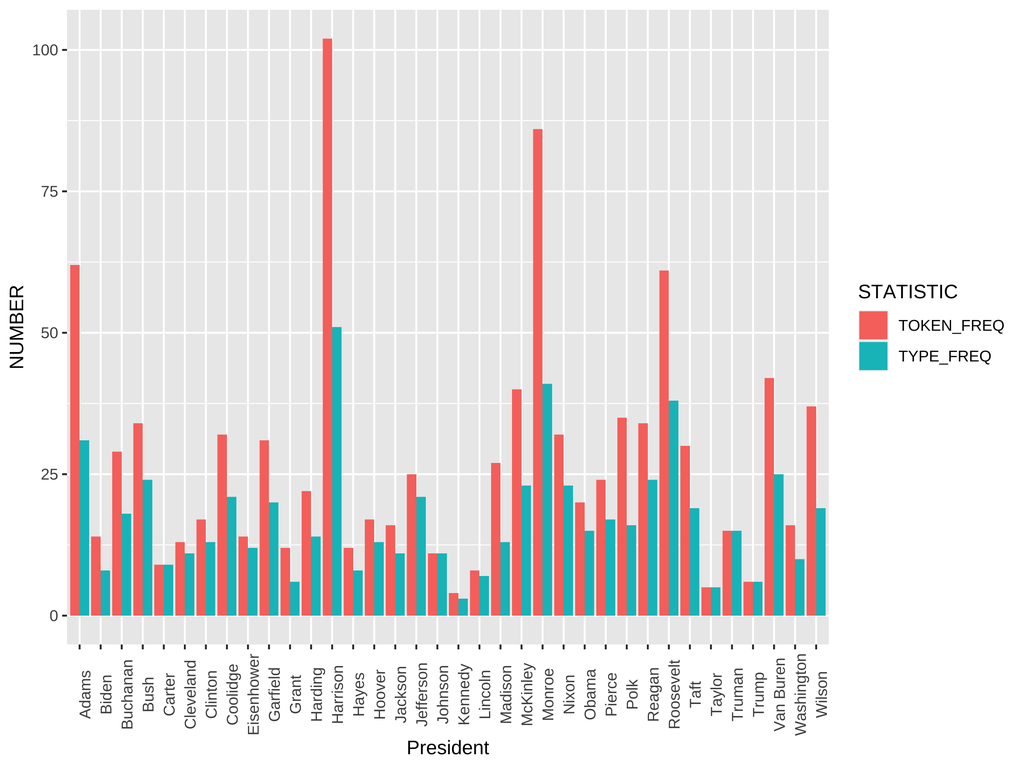

```r
# graph
result_perfect %>%
  group_by(President) %>%
  summarize(TOKEN_FREQ = n(),
            TYPE_FREQ = n_distinct(perfect)) %>%
  pivot_longer(c("TOKEN_FREQ", "TYPE_FREQ"), names_to = "STATISTIC", values_to = "NUMBER") %>%
  ggplot(aes(President, NUMBER, fill = STATISTIC)) +
           geom_bar(stat = "identity",position = position_dodge()) +
  theme(axis.text.x = element_text(angle=90))
```

There are quite a few things we need to take care of more thoroughly:

1. The auxiliary *HAVE* and the past participle do not necessarily have to stand next to each other for Perfect constructions.
2. We now lose track of one important information: from which sentence of the Presidential addresses was each construction token extracted?

Any ideas how to solve all these issues? The following exercises will be devoted to these two important issues.

Please create a better regular expression to retrieve more tokens of English Perfect constructions, where the auxilliary and participle may not stand together.

```
## [1] │ When it was first perceived, in early times, that no middle course for America remained between unlimited submission to a foreign legislature and a total independence of its claims, men of reflection were less apprehensive of danger from the formidable power of fleets and armies they must d…
##     │
##     │ The zeal and ardor of the people during the Revolutionary war, supplying the place of government, commanded a degree of order sufficient at least for the temporary preservation of society. The Confederation which was early felt to be necessary was prepared from the models of the Batavian an…
##     │
##     │ Negligence of its regulations, inattention to its recommendations, if not disobedience to its authority, not only in individuals but in States, soon appeared with their melancholy consequences  -  universal languor, jealousies and rivalries of States, decline of navigation and commerce, dis…
##     │
##     │ In this dangerous crisis the people of America were not abandoned by their usual good sense, presence of mind, resolution, or integrity. Measures were pursued to concert a plan to form a more perfect union, establish justice, insure domestic tranquillity, provide for the common defense, pro…
##     │
##     │ Employed in the service of my country abroad during the whole course of these transactions, I first saw the Constitution of the United States in a foreign country. Irritated by no literary altercation, animated by no public debate, heated by no party animosity, I read it with great satisfac…
##     │
##     │ Returning to the bosom of my country after a painful separation from it for ten years, I had the honor to be elected to a station under the new order of things, and I have repeatedly laid myself under the most serious obligations to support the Constitution. The operation of it has equaled …
##     │
##     │ What other form of government, indeed, can so well deserve our esteem and love?
##     │
##     │ There may be little solidity in an ancient idea that congregations of men into cities and nations are the most pleasing objects in the sight of superior intelligences, but this is very certain, that to a benevolent human mind there can be no spectacle presented by any nation more pleasing, …
##     │
##     │ In the midst of these pleasing ideas we should be unfaithful to ourselves if we should ever lose sight of the danger to our liberties if anything partial or extraneous should infect the purity of our free, fair, virtuous, and independent elections. If an election is to be determined by a ma…
##     │
##     │ Such is the amiable and interesting system of government (and such are some of the abuses to which it may be exposed) which the people of America have exhibited to the admiration and anxiety of the wise and virtuous of all nations for eight years under the administration of a citizen who, b…
```

Re-generate a `result_perfect` data frame, where you can keep track of:

- From the *N*-th sentence of the address did the Perfect come? (e.g., `SENT_ID` column below)
- From which president’s address did the Perfect come? (e.g., `INDEX` column below)

You may have a data frame as shown below.

| Year | President | FirstName | Party | INDEX | SENT_ID | perfect |
| --- | --- | --- | --- | --- | --- | --- |
| 1789 | Washington | George | none | 1789-Washington | 1 | have filled |
| 1789 | Washington | George | none | 1789-Washington | 2 | had chosen |
| 1789 | Washington | George | none | 1789-Washington | 4 | has been |
| 1789 | Washington | George | none | 1789-Washington | 5 | have been |
| 1789 | Washington | George | none | 1789-Washington | 5 | have then |
| 1789 | Washington | George | none | 1789-Washington | 9 | have advanced |
| 1789 | Washington | George | none | 1789-Washington | 9 | have been |
| 1789 | Washington | George | none | 1789-Washington | 9 | has resulted |
| 1789 | Washington | George | none | 1789-Washington | 9 | have been |
| 1789 | Washington | George | none | 1789-Washington | 10 | have forced |

[output cut: 984 more lines]

Re-create the above bar plot in a way that the type and token frequencies are computed based on each address and the x axis should be arranged accordingly (i.e., by the years and presidents). Your resulting graph should look similar to the one below.

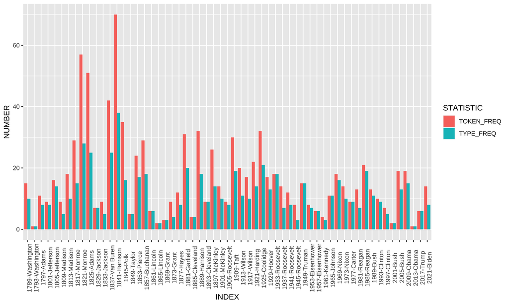

Biber, D., Conrad, S., & Cortes, V. (2004). If you look at…: Lexical bundles in university teaching and textbooks. *Applied Linguistics*, *25*(3), 371–405.

Gries, S. T. (2021). Analyzing dispersion. In *A practical handbook of corpus linguistics* (pp. 99–118). Springer.

Stefanowitsch, A. (2019). *Corpus linguistics: A guide to the methodology.* Language Science Press. Retrieved from http://langsci-press.org/catalog/book/148

Wickham, H., & Grolemund, G. (2017). *R for data science: Import, tidy, transform, visualize, and model data* (1st ed.). O’Reilly Media, Inc.